# Analyzing the Ford Gobike Dataset

## by Abdullah

## Investigation Overview

In this investigation I'm going to to look when Users start renting their bikes Also, how long their trip is affected by the users age and if the user gender is related to the user age and the trip duration.

## Dataset Overview

Ford Gobike Datasets a public bicycle sharing system represent trips taken by customers of the Ford Gobike service for the month of Feberaurary of 2019.  
Currently has over 2,600 bicycles in 262 stations. Datasets consist of 16 columns and 183412 rows

## Assoiacated Variables

duration_sec: Trip Duration (seconds).  
start_time: Start Time and Date.  
end_time: End Time and Date  
start_station_id: Start Station ID  
start_station_name: Start Station Name  
start_station_latitude: Start Station Latitude  
start_station_longitude: Start Station Longitude  
end_station_id: End Station ID  
end_station_name: End Station Name  
end_station_latitude: End Station Latitude  
end_station_longitude: End Station Longitude  
bike_id: Bike ID  
user_type: User Type (Subscriber or Customer)  
member_birth_year: Member Year of Birth  
member_gender: Member Gender  
bike_share_for_all_trip: members "Bike Share for All" program for low-income residents

## Distribution of the users Age

### Increasing the number of users as the increase of the user Age starting from age 20 years old till the peak with maximum nuber of user at age about 30 years old and then start to decrease again and almost there are no users above 80 years old.

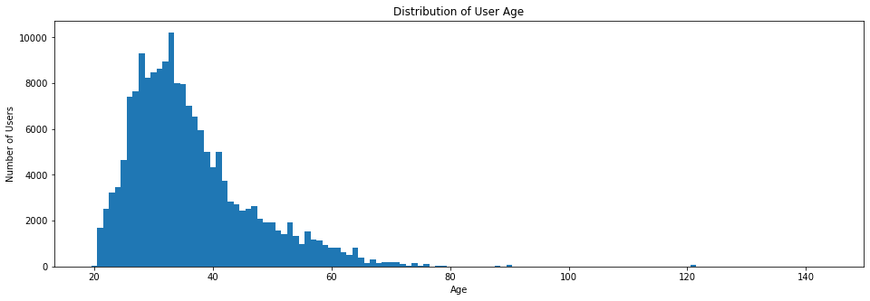

## Duration of the Bike trip by user age

### Most of the durations are less than 20000 sec and Duration of the bike trip start to decrease at age above 50 years old

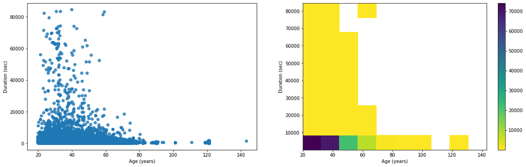

## Duration of the Bike trip over the user Age by user Gender

### It seems that the Men gender at age between 20 and 50 yers old spent more time in their bike trip than Female gender at the same age period

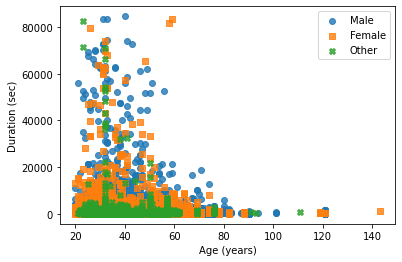

### Both Customer users and Suscriber User showing similar distribution of the age and as expected Suscriber represent more Users than Customers

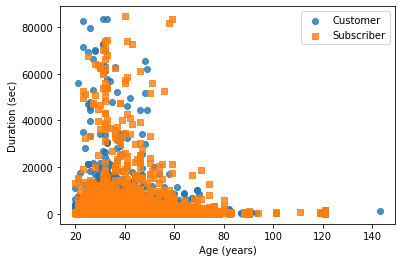

## Count of bike-users by weekday type

[figure not shown]